# Unit 5

### 1) **Quality Assurance (QA) and its Levels**

**Quality Assurance (QA):**  
QA involves reviewing system or software products and documentation to ensure they meet specified requirements and standards. The primary purpose is to provide confidence to customers by delivering consistent products that meet specifications.

**Levels of QA:**  
- **Level 1: Code Walk-through**  
Offline review of code to identify violations of coding rules, focusing on documentation and in-code comments.  
- **Level 2: Compilation and Linking**  
Verifies that the software compiles and links across all platforms and operating systems.  
- **Level 3: Routine Running**  
Tests software under various conditions, such as varying event sizes and scenarios.  
- **Level 4: Performance Test**  
Ensures the software satisfies the predefined performance standards.

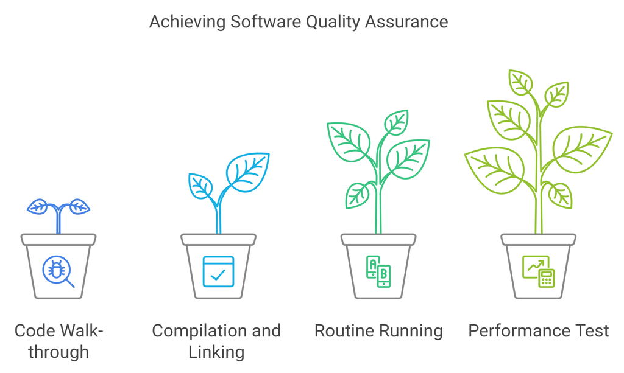

### 2) **Stages of System Testing**

System testing ensures the system functions as expected under various conditions. It consists of several stages:

1. **Test Strategy**
   - Defines levels, methods, tools, and techniques for testing.
   - Aligns with organizational requirements.
2. **Test Plan**
   - Outlines objectives for each test phase, tools, and responsibilities.
   - Covers time requirements, test libraries, and standards for planning.
3. **Test Case Design**
   - Specifies how requirements or design decisions are tested.
   - Includes criteria for success and documents these in a test specification.
4. **Test Procedures**
   - Details steps to execute test cases, often recorded in a test procedure specification.
5. **Test Result Documentation**
   - Summarizes executed test cases, errors, and their nature.
   - Assessed against test specification criteria to determine the outcome.

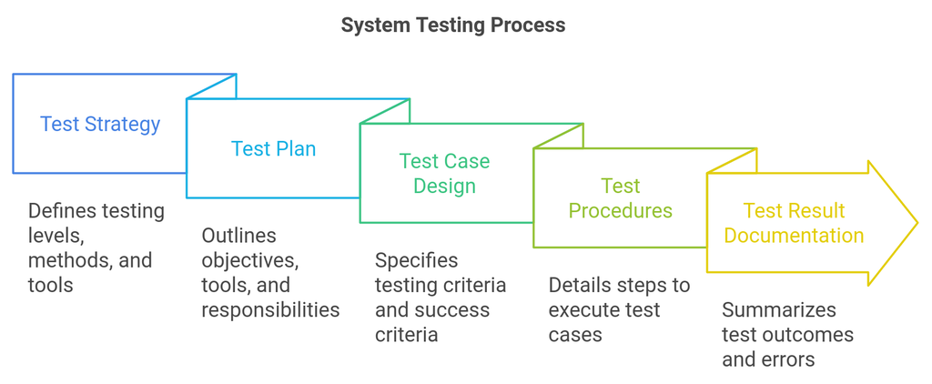

### 3) **Types of Testing**

- **Unit Testing**
  - Focuses on individual modules or programs.
  - Ensures each program executes every statement at least once.
- **Integration Testing**
  - Tests multiple modules working together.
  - Identifies discrepancies in data formats, indices, and file sizes.
- **Functional Testing**
  - Confirms the system meets functional specifications.
  - **Positive Functional Testing:** Uses valid inputs to verify correct outputs.
  - **Negative Functional Testing:** Tests invalid inputs to check for errors.
- **Other Rules for System Testing:**
  - Testing should be based on user requirements and business logic.
  - Both valid and invalid inputs must be tested.
  - Testing should involve both static and dynamic methods.

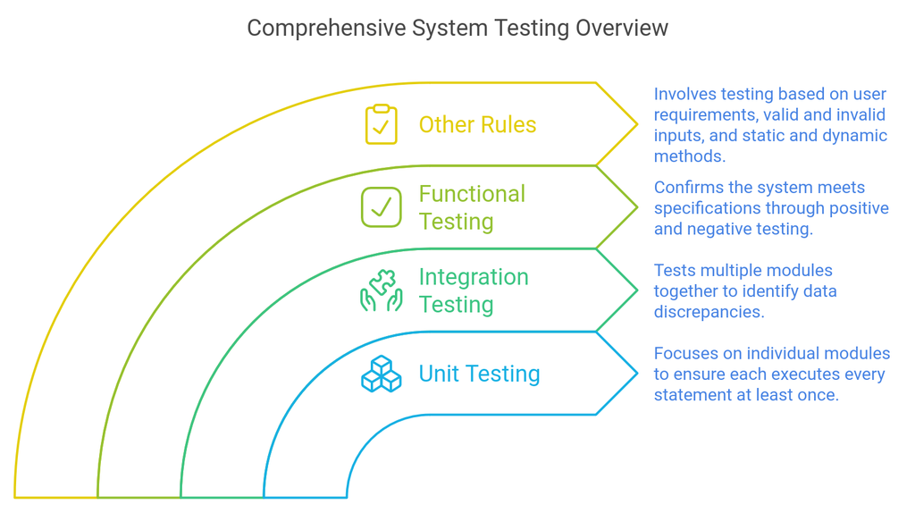